# Instrumentation

Joseph Moerschell, Marc Nicollerat

# 6 Capteurs incrémentaux

- Capteurs rotatifs et linéaires
- Capteurs incrémentaux ou absolus

## 6.1 Capteur incrémental de position angulaire

- Le capteur génère des impulsions lorsque l’arbre tourne
- La résolution peut varier selon le capteur. Il dépend du nombre de stries du disque.

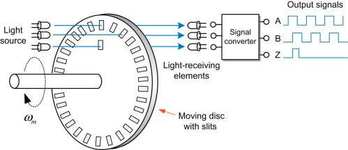

Principe du codeur incrémental

## 6.2 Principe de comptage

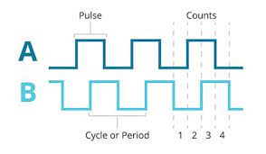

Principe de comptage

La séquence des signaux permet de compter en avant ou en arrière.

**Exercice**

Vérifiez la séquence des signaux selon que le capteur tourne en avant ou en arrière

## 6.3 Calcul de la vitesse

La vitesse de rotation ou de déplacement peut être calculée de 2 façons :

1. Mesure du nombre d’incréments sur une période de calcul du processus.

   Si à l’instant t1, le compteur vaut p1, à l’instant t2, le compteur vaut p2, on peut déduire la vitesse ainsi : $v=\frac{p2-p1}{t2-t1}$

   Cette méthode fonctionne bien si la *vitesse est élevée*.
2. Mesure du temps entre 2 transitions. Un *timer* du processeur peut mesurer le temps avec une bonne résolution.

   Pour une *fréquence suffisante*, le compteur atteint une valeur suffisamment grande pour avoir une bonne précision.

   La *taille du compteur* peut poser problème aux vitesse lentes (débordement).

**Exercice**

Le jupyter notebook ex_6.1_vitesse-codeur-incremental_sol propose un exercice de comparaison.

## 6.4 Capteur absolu de position angulaire

Dans sa version la plus simple, un codeur absolu fournit autant de bits que le demande sa résolution :

Pour une résolution de 1024, il fournit 10 bits

- Ce genre d’interface utilise le *Code de Gray*. L’information est codée de telle sorte qu’un seul signal ne change en même temps
- Information absolue sous forme de code

[figure not shown]

Code de Gray

Les interfaces du capteur sont multiples

- Un contact par bit (code de Gray)
- Interface série,
- Signal codé en binaire avec un signal *Enable*
- …

## 6.5 Capteur incrémental de position linéaire

- Même principe, mais sur une règle
- Possibilités de codage étendues : la position peut être codée sur la régle pour avoir une position absolue avec une grande résolution.

[figure not shown]

Codeur absolu Heidenhain

## 6.6 Augmentation de la résolution d’un capteur incrémental

- Le signal numérique est remplacé par 2 sorties sin/cos
- On peut en déduire une position intermédiaire

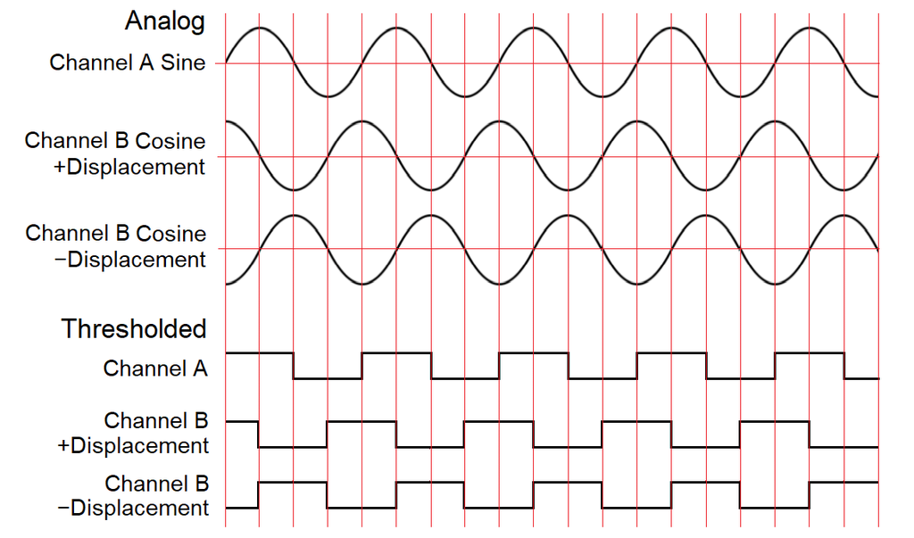

Sortie sin/cos

## 6.7 Capteur de vitesse magnétique incrémental

Sur un moteur de thermique, on a besoin de la position du vilebrequin pour déclencher l’allumage très précisément. Le principe du capteur utilise une “roue phonique” (allusion aux orgues Hammond).

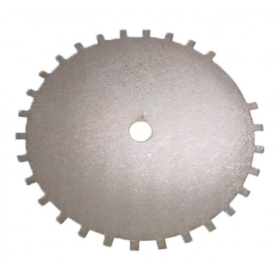

Roue phonique

[figure not shown]

Capteur régime inductif

Le principe utilise la variation du circuit magnétique généré par la rotation de la roue phonique. Ceci induit une tension dans le capteur.

## 6.8 Variations

- Codage magnétique ou optique des positions
- Mix de technologies
- Capteur optique comportant beaucoup de points, lecture avec une caméra

## 6.9 Liens

- [Quelques animations sur les capteurs](https://www.tecnipass.com/cours-electronique.cem-numerique-hexadecimal.gray.bcd?page=3)

## 6.10 Exercices

**Cyberlearn**

- Capteur incrémental de position

**Casse-tête**

Un codeur incrémental placé sur le moteur d’une transmission subit le jeu du réducteur du moteur. On mesure la position d’un objet entraîné par cette transmission à l’aide du codeur. La transmission fait tourner le tambour d’un tapis roulant, l’objet est posé sur le tapis.

- Comment estimer l’influence du jeu sur la précision de la mesure ?
  - Définissez comment qualifier le jeu, définissez un paramètre pour ça.
  - Trouvez les paramètres qui interviennent dans ce calcul.
  - Comment pouvez-vous donner une valeur à tous ces paramètres si vous êtes près de l’installation ?
- Comment limiter l’influence du jeu ?